# Creating a 3-Layer Deep Neural Net for Binary Classification

[figure not shown]

## Outline

In this project, I created a 3-layer Deep Neural Network that can be used for Binary Classification, utilizing the theory I learned in Andrew Ng's [Deep Learning Specialization](https://www.coursera.org/specializations/deep-learning). I then tested the model by assessing its ability to differentiate various swimming strokes from each other. A 3-layer neural network can be considered a deep neural network because it has multiple hidden layers. The increased depth of the network (compared to a shallow neural net) enables it to learn increasingly abstract representations of the input data, leading to more accurate predictions and insights. As there are 3 layers, we must choose 3 suitable activation functions. For this model, we will use the following:

- `ReLU` for the 2 hidden layers:
  - Need a non-linear activation function inside the hidden layers. If we were to use linear activation functions, the neural network would simply become a giant linear regression model that is useless for learning complex (non-linear) patterns.
  - Gradient descent converges faster when using `ReLU` compared to other activation functions (e.g. `tanx`). This is because it has a constant gradient and is easily differentiable (everywhere except 0). The function is defined as follows:

[figure not shown]

- `sigmoid` for the final (output) layer:
  - Required for the final layer here because we wish to use the model to perform Binary classification - sigmoid scales the input to a probability between 0 and 1:

[figure not shown]

The neural net will consist of several steps outlined in the following diagram (note L denotes the number of layers in the network (3 here)):

[figure not shown]

In this project we first define each step individually in the form of helper functions before combining them into a single function that can be used to train the model.

Since these models can be potentially very complex with many nodes at each layer, code efficiency becomes especially important. For this reason, we will use vectorization wherever possible to make use of parallel processing.

Before we start, lets import the required library's:

```python
# Library imports
import numpy as np
import matplotlib.pyplot as plt
import seaborn
from skimage.io import imread_collection

from sklearn.model_selection import train_test_split
from sklearn.metrics import confusion_matrix
```

## Helper functions

### Activation functions

First we create the `ReLU` and `sigmoid` activation functions. We will also need to define their derivatives (`relu_backward` and `sigmoid_backward`) for the back propagation step. Note this is simply $RELU'(Z) = 0$ $if Z < 0$, 1 $otherwise $ for `ReLU`, and $\sigma'(Z) = \sigma(Z) * (1- \sigma(Z))$ for `sigmoid` which can (relatively easily) be derived by taking the derivative of $\frac{1}{ 1 + e^{-(W A + b)}}$

```python
# Activation functions for forward propagation:
def sigmoid(Z):
    cache = Z
    A = 1/(1+np.exp(-Z))

    return A, cache

def relu(Z):
    cache = Z
    A = np.maximum(0,Z)

    assert(A.shape == Z.shape)

    return A, cache


# ... and for backward propagation:
def relu_backward(dA, cache):
    Z = cache
    dZ = np.array(dA, copy=True) # converting dZ to the correct object
    dZ[Z <= 0] = 0
    assert (dZ.shape == Z.shape) # Enforce the correct shape

    return dZ

def sigmoid_backward(dA, cache):
    Z = cache
    s = 1/(1+np.exp(-Z))
    dZ = dA * s * (1-s)
    assert (dZ.shape == Z.shape) # Enforce the correct shape

    return dZ
```

### Initialize

Next we create the initialize function, which will initialize the weight matrices and bias vectors for each layer of the neural network. The key components of this part are:

- **Getting the layer dimensions right** - the dimensions of the weights, biases, and activations should be as follows:

  |  | **Shape of W** | **Shape of b** | **Shape of Activation** |
  | --- | --- | --- | --- |
  | **Hidden layer 1** | (n1, nFeatures) | (n1, 1) | (n1, m) |
  | **Hidden layer 2** | (n2, n1) | (n2, 1) | (n2, m) |
  | **Output layer** | (nOutput, n2) | (nOutput, 1) | (nOutput, m) |

  .
  - where
    - *m*: number of training examples
    - *nFeatures*: number of features in the input layer
    - *n1*: nodes in layer 1,
    - *n2*: nodes in layer 2
    - *nOutput*: nodes in output layer
- **Randomly selecting each weight** -The weights cannot be initialized to the same value (e.g., 0) because this would lead to all nodes in a given layer calculating 'the same thing.' Consequently, the use of multiple nodes would become redundant, rendering it equivalent to having only one node. This is called the *symmetry breaking problem*. - We can solve this issue by *randomly* initializing each weight, followed by multiplying the result by a small number (to give faster convergence during gradient descent)
  - Note that the bias terms do not need to be randomly initialized and can simply be set to 0, since if the weights are randomly initialized the bias terms won't have the *symmetry breaking problem*

```python
def initialize_parameters(n_x, n_h1, n_h2, n_y):
   """
   Args:
    n_x -- size of the input layer
    n_h1 -- size of the first hidden layer
    n_h2 -- size of the second hidden layer
    n_y -- size of the output layer

    Returns:
    parameters -- python dictionary containing the following parameters:
                    W1 -- weight matrix of shape (n_h1, n_x)
                    b1 -- bias vector of shape (n_h1, 1)
                    W2 -- weight matrix of shape (n_h2, n_h1)
                    b2 -- bias vector of shape (n_h2, 1)
                    W3 -- weight matrix of shape (n_y, n_h2)
                    b3 -- bias vector of shape (n_y, 1)
   """

    # Initialize
   W1 = np.random.randn(n_h1, n_x) * 0.01
   b1 = np.zeros((n_h1, 1))
   W2 = np.random.randn(n_h2, n_h1) * 0.01
   b2 = np.zeros((n_h2, 1))
   W3 = np.random.randn(n_y, n_h2) * 0.01
   b3 = np.zeros((n_y,1))

   # Store results in a dictionary
   parameters = {"W1": W1,
                 "b1": b1,
                 "W2": W2,
                 "b2": b2,
                 "W3": W3,
                 "b3": b3}

   return parameters
```

### Forward propagation

We now need to define the forward propagation steps of the model. The mathematical relation is: $A^{[l]} = g(Z^{[l]}) = g(W^{[l]}A^{[l-1]} +b^{[l]})$ where the activation $g(.)$ can be sigmoid() or relu(). This can be split into two components: a `linear_forward` function for the linear part, and `linear_activation_forward` for the activation part:

```python
def linear_forward(A, W, b):
    """Forward propagation for the linear part of a layer"""

    # Calculate Z (linear component)
    Z = np.dot(W, A) + b

    # cache current values for A, W, and b
    cache = (A, W, b)
    return Z, cache


def linear_activation_forward(A_prev, W, b, activation):
    """Forward propagation for the LINEAR->ACTIVATION part of a layer"""

    # Sigmoid case
    if activation == "sigmoid":
        Z, linear_cache = linear_forward(A_prev, W, b)
        A, activation_cache = sigmoid(Z)

    # RELU case
    elif activation == "relu":
        Z, linear_cache = linear_forward(A_prev, W, b)
        A, activation_cache = relu(Z)

    cache = (linear_cache, activation_cache)

    return A, cache
```

### Cost function

We also need to define a suitable cost function $J$. We do so using the `cross-entropy` cost function defined as: $$-\frac{1}{m} \sum\limits_{i = 1}^{m} (y^{(i)}\log\left(a^{[L] (i)}\right) + (1-y^{(i)})\log\left(1- a^{[L](i)}\right)) $$ which in this case will give the average loss across all the examples for the nodes in the output layer of the neural network. We implement a vectorized version for computational efficiency:

```python
def compute_cost(AL, Y):
    """Compute the cross-entropy cost"""
    cost = 0
    m = Y.shape[1] # number of training examples

    logprobs = np.multiply(np.log(AL),Y) + (1 - Y) * np.log(1 - AL)
    cost = -(1/m) * np.sum(logprobs)

    cost = np.squeeze(cost)

    return cost
```

### Backwards Propagation

Now that we've propagated forwards and calculated an output probability, we need to perform backwards propagation in order for the model to learn better weights and biases. This is done by calculating the derivatives of the cost function with respect to the weights and biases at each layer. We can then use these derivatives to update the weights and biases during gradient descent. The key components of this part are a `linear_backward` and `linear_activation_backward` step, defined mathematically as:

- `linear_backward`:
  - Calculate the derivative $dZ^{[l]} = \frac{\partial \mathcal{L} }{\partial Z^{[l]}}$ and use to get $(dW^{[l]}, db^{[l]}, dA^{[l-1]})$, where `l` is the current layer, using the following formulae:

  $$ dW^{[l]} = \frac{\partial \mathcal{J} }{\partial W^{[l]}} = \frac{1}{m} dZ^{[l]} A^{[l-1] T}$$ $$ db^{[l]} = \frac{\partial \mathcal{J} }{\partial b^{[l]}} = \frac{1}{m} \sum_{i = 1}^{m} dZ^{[l](i)}$$ $$ dA^{[l-1]} = \frac{\partial \mathcal{L} }{\partial A^{[l-1]}} = W^{[l] T} dZ^{[l]}$$
- `linear_activation_backward`:
  - Use the `sigmoid_backward` and `relu_backward` helper functions to compute $$dZ^{[l]} = dA^{[l]} * g'(Z^{[l]})$$ where $g(.)$ is the activation function of the layer being considered.

```python
def linear_backward(dZ, cache):
    """Function that calculates the linear component of the backward propagation step"""
    A_prev, W, b = cache
    m = A_prev.shape[1]

    dW = (1/m) * np.dot(dZ, A_prev.T)
    db = (1/m) * np.sum(dZ, axis = 1, keepdims = True) # need keepdims for correct broadcasting
    dA_prev = np.dot(W.T, dZ)

    return dA_prev, dW, db


def linear_activation_backward(dA, cache, activation):
    """ Function that calculates activation part of back propagation """

    # Retrieve the linear and activation cache created during forward propagation
    linear_cache, activation_cache = cache

    # RELU case
    if activation == "relu":
        dZ = relu_backward(dA, activation_cache)
        dA_prev, dW, db = linear_backward(dZ, linear_cache)

    # Sigmoid case
    elif activation == "sigmoid":
        dZ = sigmoid_backward(dA, activation_cache)
        dA_prev, dW, db = linear_backward(dZ, linear_cache)

    return dA_prev, dW, db
```

### Update parameters

All that remains now is to define a helper function that updates the weights and biases stored in the `parameters` dictionary to the new values calculated in the backwards propagation step:

```python
def update_parameters(params, grads, learning_rate):
    parameters = params.copy()

    # Loop over each layer and update parameters
    for l in range(3):
        parameters["W" + str(l+1)] = params["W" + str(l+1)] - learning_rate * grads["dW" + str(l+1)]
        parameters["b" + str(l+1)] = params["b" + str(l+1)] - learning_rate * grads["db" + str(l+1)]

    return parameters
```

## 3-Layer Neural Net

Now that all the required helper functions have been created, we can combine them to implement a 3-Layer Neural Net!

```python
def three_layer_model(X, Y, layers_dims, learning_rate = 0.1, num_iterations = 3000, print_cost=False):
    """
    Implements a three-layer neural network: LINEAR->RELU->LINEAR->SIGMOID.

    Args:
    X: input data
    Y: true "label" vector (containing 1 if stroke if fly, 0 otherwise)
    layers_dims -- dimensions of the layers (n_x, n_h1, n_h2, n_y)
    num_iterations -- number of iterations of gradient descent to be performed
    learning_rate -- learning rate of the gradient descent update rule
    print_cost -- If set to True, this will print the cost every 100 iterations

    Returns:
    parameters -- a dictionary containing the final weight and bias values
    """

    np.random.seed(420) # set seed for reproducibility

    # Initialize a dictionary and list to keep track of the grad and cost values
    grads = {}
    costs = []

    # Extract the layer dimensions and initialize parameters
    (n_x, n_h1, n_h2, n_y) = layers_dims
    parameters = initialize_parameters(n_x, n_h1, n_h2, n_y)

    # Retrieve weights and biases from parameters dictionary
    W1 = parameters["W1"]
    b1 = parameters["b1"]
    W2 = parameters["W2"]
    b2 = parameters["b2"]
    W3 = parameters["W3"]
    b3 = parameters["b3"]

    # Perform gradient descent
    for i in range(0, num_iterations):
        # Forward Propagation (relu -> relu -> sigmoid)
        A1, cache1 = linear_activation_forward(X, W1, b1, "relu")
        A2, cache2 = linear_activation_forward(A1, W2, b2, "relu")
        A3, cache3 = linear_activation_forward(A2, W3, b3, "sigmoid")

        # Compute cost
        cost = compute_cost(A3, Y)

        # Backward Propagation
        dA3 = - (np.divide(Y, A3) - np.divide(1 - Y, 1 - A3))
        dA2, dW3, db3 = linear_activation_backward(dA3, cache3, "sigmoid")
        dA1, dW2, db2 = linear_activation_backward(dA2, cache2, "relu")
        dA0, dW1, db1 = linear_activation_backward(dA1, cache1, "relu")

        # Store grads
        grads['dW1'] = dW1
        grads['db1'] = db1
        grads['dW2'] = dW2
        grads['db2'] = db2
        grads['dW3'] = dW3
        grads['db3'] = db3

        # Update parameters
        parameters = update_parameters(parameters, grads, learning_rate)

        # Retrieve W1, b1, W2, b2 from parameters
        W1 = parameters["W1"]
        b1 = parameters["b1"]
        W2 = parameters["W2"]
        b2 = parameters["b2"]
        W3 = parameters["W3"]
        b3 = parameters["b3"]

        # Print the cost every 100 iterations
        if print_cost and i % 100 == 0 or i == num_iterations - 1:
            print("Cost after iteration {}: {}".format(i, np.squeeze(cost)))
        if i % 100 == 0 or i == num_iterations:
            costs.append(cost)

    # Plotting the cost function vs the number of iterations
    plt.plot(np.squeeze(costs))
    plt.ylabel('cost')
    plt.xlabel('iterations (per hundreds)')
    plt.title("Learning rate =" + str(learning_rate))
    plt.show()

    return parameters, costs
```

### Predictions

We also define a function that can be used to make predictions once the model's parameters have been trained. This is achieved by performing one step of forward propagation on the input data using the final weights + biases of the trained model:

```python
def predict(parameters, X):
    """
    Using the learned parameters, predicts a class for each example in X

    Arguments:
    parameters -- python dictionary containing the trained parameters
    X -- input data of size (n_x, m)

    Returns
    predictions -- vector of predictions of our model (butterfly: 1 / other: 0)
    """
    # Retrieve weights and biases from parameters dictionary
    W1 = parameters["W1"]
    b1 = parameters["b1"]
    W2 = parameters["W2"]
    b2 = parameters["b2"]
    W3 = parameters["W3"]
    b3 = parameters["b3"]

    # Forward Propagation (relu -> relu -> sigmoid)
    A1, cache1 = linear_activation_forward(X, W1, b1, "relu")
    A2, cache2 = linear_activation_forward(A1, W2, b2, "relu")
    A3, cache3 = linear_activation_forward(A2, W3, b3, "sigmoid")

    # Adding predictions to list
    # Set to 1 if > 0.5, 0 otherwise
    predictions = (A3 > 0.5).astype(int)

    return predictions
```

## Applying the model

We will test the model's binary classification abilities on a swimming image dataset. I've been swimming competitively for the last 12 years and so I figured this to be a satisfying way to test my neural network! The dataset contains a collection of swimmers performing different strokes, and we will test the model's ability to recognise the butterfly stroke from the other strokes - a binary classification problem (`fly` (1) vs `non-fly` (0)). I've chosen fly because the data happens to contain a lot of instances of this stroke, and it also quite recognisable due to the swimmer's arms being outstretched on each side during the recovery phase. The dataset I used can be found [here](https://images.cv/dataset/swimming-image-classification-dataset)

Unfortunately the the labels had to be created manually by visualling checking whether each image contains a fly or non-fly stroke, which proved to be rather tedious!

### Importing the data

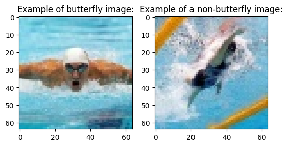

```python
# Importing the images
X_orig = imread_collection('images/*.jpg')

# Manually labelling the data
# 1: Fly, 0: other stroke
Y = np.array([0, 0, 0, 1, 0, 0, 0, 0, 0, 0, 0, 0, 0, 0, 0, 0, 0, 0, 0, 0, 0, 0, 0, 0, 0, 0, 0, 0, 0,
			  0, 1, 0, 0, 0, 0, 0, 0, 0, 0, 0, 0, 0, 1, 0, 0, 0, 0, 0, 0, 0, 0, 0, 0, 0, 1, 0, 0, 0,
			  0, 0, 0, 0, 0, 0, 0, 0, 0, 0, 0, 0, 0, 0, 0, 0, 0, 0, 0, 0, 0, 0, 0, 0, 0, 0, 1, 0, 0,
			  0, 0, 0, 0, 0, 0, 0, 0, 0, 1, 1, 1, 0, 0, 0, 0, 0, 0, 0, 0, 0, 0, 0, 1, 0, 0, 0, 0, 0,
			  0, 0, 0, 0, 0, 0, 0, 1, 0, 0, 0, 0, 0, 0, 0, 1, 0, 0, 0, 0, 1, 0, 0, 0, 0, 0, 0, 1, 0,
			  0, 0, 1, 0, 0, 0, 0, 0, 0, 0, 0, 0, 0, 0, 0, 0, 0, 0])

# Example of a butterfly image
plt.subplot(1, 2, 1)
plt.imshow(X_orig[3])
plt.title("Example of butterfly image:")

# Example of a non-fly image
plt.subplot(1, 2, 2)
plt.imshow(X_orig[1])
plt.title("Example of a non-butterfly image:")

plt.show()
```

Checking I've labelled correctly (swimmers in each plot should be swimming fly)

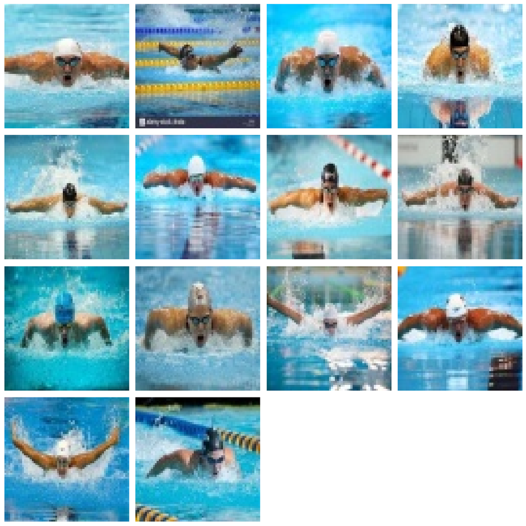

```python
# Store indices of images corresponding to Y[] = 1 (fly images)
x = []
for i in range(len(Y)):
    if Y[i] == 1:
        x.append(i)

# Set up subplot grid
num_rows = len(x) // 4
num_cols = 4
if len(x) % 4 != 0:
    num_rows += 1
    num_empty_plots = (num_rows * num_cols) - len(x)
    fig, axs = plt.subplots(num_rows, num_cols, figsize=(12, num_rows*3))

    # Plot images
    for i in range(len(x)):
        row = i // 4
        col = i % 4

        axs[row, col].imshow(X_orig[x[i]])
        axs[row, col].axis('off')

    # Remove potentially empty plots on the last row
    for i in range(num_empty_plots):
        axs[-1, -1-i].axis('off')

else:
    fig, axs = plt.subplots(num_rows, num_cols, figsize=(12, num_rows*3))

    # Plot images
    for i in range(len(x)):
        row = i // 4
        col = i % 4

        axs[row, col].imshow(X_orig[x[i]])
        axs[row, col].axis('off')

plt.tight_layout()
plt.show()
```

After a couple failed attempts, the fly images have (thankfully) been labelled correctly!

### Data preprocessing

Let's first split the data into train and test sets - we will use a 50/50 train/test split as there is limited data/positive instances. Since there are more positive instances in the second half of the dataset, we will use the second half for training as this gives the model more butterfly examples to learn from. We also double check that all the dimensions are correct:

```python
# Convert the images into a numpy array
X_orig = np.stack(X_orig)

# Split the data into train and test sets
X_train_orig = X_orig[int(len(X_orig)*0.5):]
X_test_orig = X_orig[:int(len(X_orig)*0.5)]
Y_train = Y[int(len(Y)*0.5):]
Y_test = Y[:int(len(Y)*0.5)]

# Reshaping the labels for the train and test set
Y_train = Y_train.reshape(1, Y_train.shape[0])
Y_test = Y_test.reshape(1, Y_test.shape[0])

# Checking the dimensions
m_train = X_train_orig.shape[0]
num_px = X_train_orig.shape[1]
m_test = X_test_orig.shape[0]

print ("Number of training examples: " + str(m_train))
print ("Number of testing examples: " + str(m_test))
print ("Each image is of size: (" + str(num_px) + ", " + str(num_px) + ", 3)")
print ("train_x_orig shape: " + str(X_train_orig.shape))
print ("train_y shape: " + str(Y_train.shape))
print ("test_x_orig shape: " + str(X_test_orig.shape))
print ("test_y shape: " + str(Y_test.shape))
```

```
Number of training examples: 82
Number of testing examples: 81
Each image is of size: (64, 64, 3)
train_x_orig shape: (82, 64, 64, 3)
train_y shape: (1, 82)
test_x_orig shape: (81, 64, 64, 3)
test_y shape: (1, 81)
```

Before we feed the images into the neural network, we will reshape and standardise. We "flatten" the image into a vector of shape (num_px * num_px * 3, 1), as this shape is required for the data be fed into the neural network. We also standardise by dividing by 255 - in RGB (Red-Green-Blue) images, each pixel is represented by three color channels, and the intensity of each channel ranges from 0 to 255. By dividing each pixel value by 255, we scale the values down to the range of 0 to 1. Standardizing RGB images in this way is a common preprocessing step that helps improve the stability, convergence, and efficiency of neural network training, leading to better performance and generalisation.

```python
# Reshape the training and test examples
train_x_flatten = X_train_orig.reshape(X_train_orig.shape[0], -1).T   # The "-1" makes reshape flatten the remaining dimensions
test_x_flatten = X_test_orig.reshape(X_test_orig.shape[0], -1).T

# Standardize data to have feature values between 0 and 1.
X_train = train_x_flatten/255.
X_test = test_x_flatten/255.

# Checking the dimensions
print ("train_x's shape: " + str(X_train.shape))
print ("test_x's shape: " + str(X_test.shape))
```

```
train_x's shape: (12288, 82)
test_x's shape: (12288, 81)
```

### Training the model

Before we can train the model, we need to define the layer dimensions. The size of n_x and n_y (first and last layer respectively) are fixed due to the shape of the input data and nature of the output, but we are free to choose the number of nodes in each hidden layer. We will use 20 and 5 for the first and second hidden layers respectively:

```
Cost after iteration 0: 0.6930682648353274
Cost after iteration 100: 0.32335348330202174
Cost after iteration 200: 0.1375466028405784
Cost after iteration 300: 0.09048349938465146
Cost after iteration 400: 0.05945371444966443
Cost after iteration 500: 0.04333378889091911
Cost after iteration 600: 0.03240477001908592
Cost after iteration 700: 0.02583774826582618
Cost after iteration 800: 0.02130290430557426
Cost after iteration 900: 0.01805188116702416
Cost after iteration 1000: 0.015617300547668515
Cost after iteration 1100: 0.013867951037599455
Cost after iteration 1200: 0.012247665222659255
Cost after iteration 1300: 0.011032778651277978
Cost after iteration 1400: 0.010040500924335631
Cost after iteration 1499: 0.009186516916644252
```

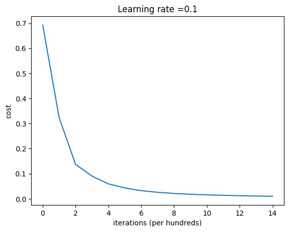

```python
# Defining the layer dimensions
n_x = 12288     # num_px * num_px * 3
n_h1 = 20
n_h2 = 5
n_y = 1
layers_dims = (n_x, n_h1, n_h2, n_y)

# Training the model using the training set
parameters, costs = three_layer_model(X_train, Y_train, layers_dims, num_iterations = 1500, print_cost = True)
```

### Evaluating model performance on the train and test set

#### Train set

```
Accuracy of the training set predictions: 100.0 %
Confusion matrix for the training set
```

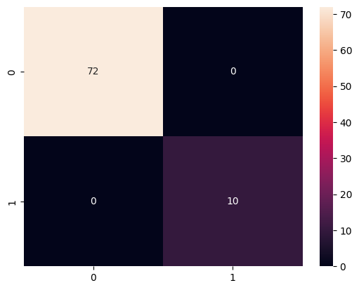

```python
# Evaluating on the train set
train_predictions = predict(parameters, X_train).flatten()
Y_train = Y_train.flatten()

# Calculating the accuracy
correct = 0
for i in range(len(train_predictions)):
    if (train_predictions[i] == Y_train[i]):
        correct += 1

accuracy = (correct/len(train_predictions)) * 100
print ("Accuracy of the training set predictions: {} %".format(accuracy))

# Producing a Consufion Matrix for the training set predictions
print("Confusion matrix for the training set")
matrix = confusion_matrix(Y_train, train_predictions)
seaborn.heatmap(matrix, annot=True, fmt='d')
plt.show()
```

As seen above, the model can predict the training set with 100% accuracy, with zero images being missclassified. We do however run the risk of overfitting - due to the complexity of neural networks they're usually able to model the training data well, but they're of no use if they can't generalise to new data. The model's generalisation ability can be assessed by evaluating the models predictions on the test set.

#### Test set

```
Accuracy of the training set predictions: 97.53086419753086 %
Confusion matrix for the testing set
```

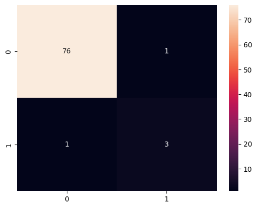

```python
# Evaluating on the test set
test_predictions = predict(parameters, X_test).flatten()
Y_test = Y_test.flatten()

# Calculating the accuracy
correct = 0
for i in range(len(test_predictions)):
    if (test_predictions[i] == Y_test[i]):
        correct += 1

accuracy = (correct/len(test_predictions)) * 100
print ("Accuracy of the training set predictions: {} %".format(accuracy))

# Confusion matrix
print("Confusion matrix for the testing set")
matrix = confusion_matrix(Y_test, test_predictions)
seaborn.heatmap(matrix, annot=True, fmt='d')
plt.show()
```

From this we see that the model has generalised well - the predictions made on the test set had an accuracy of 97.5%, with only two images being missclassified (1 false positive and 1 false negative). The model performs very well at identifying non-fly stroke images whilst also being able to identify most fly stroke images (3/(3+1) = 3/4 (75% of them)). The number of images in the test set is quite small and it would've been better to test the model on more data if it were available; nonetheless the prediction accuracy here is certainly a good indication that the model performs the task well.

### Improvements

- The choice of the hidden layers dimension (20, 5) was made quite arbitrarily. There is likely a different combination of layer dimensions that could produce better performance for this problem.
- Use more data. The dataset used here was quite small, and the model's performance could be assessed more robustly using more data.
  - Using more data may have required us to use `early stopping` to prevent overfitting - this wasn't necessary here though, given the model generalised well to the test set.
- Only a single train/test split was used to evaluate the model's performance. In general it's good practice to perform `K-fold Cross Validation` to get a more robust estimate of the model's performance, however this wouldn't be appropriate for the current dataset due to the limited number of positive instances.

### Conclusion

This marks the end of the project. Creating a deep neural net as opposed to using pre-built libraries was a great learning experience, and I now have a much better understanding of how neural networks work. Overall I'm happy with the model's performance, and the use of swimming images was a fun way to test my implementation. If you've made it this far, thanks for reading!

*James Portier*